# Random Forest Regression

Author : Rose Ellison

I will be building a random forest regression model based off the ‘Position_Salaries’ data to determine 1.) determine if the model fits the data and 2.) to determine if a particuilar new hire’s past salary was possibly $160,000 as a region manager. In this dataset there are three columns $Position$, $Level$, and $Salary$. Salary is our dependent variable while the other two are our independent variables.

# Preparing the Data

```r
# Set the seed
set.seed(1)

# Importing the data
positions <- read.csv('../../data/Position_Salaries.csv')

# Examine the Data
dim(positions)
```

```
## [1] 10  3
```

```r
positions
```

```
##             Position Level  Salary
## 1   Business Analyst     1   45000
## 2  Junior Consultant     2   50000
## 3  Senior Consultant     3   60000
## 4            Manager     4   80000
## 5    Country Manager     5  110000
## 6     Region Manager     6  150000
## 7            Partner     7  200000
## 8     Senior Partner     8  300000
## 9            C-level     9  500000
## 10               CEO    10 1000000
```

From the table we can see there is some redundancy between the $Position$ and $Level$ column. Therefor it would make sense to drop the $Position$ column and just use the numeric $Level$ and $Salary$ columns. Since we only have 10 observations, it would not be useful to split the data into a training and test set.

```r
# Saving the dataset with only the two necessary columns
positions <- positions[, 2:3]
```

```r
set.seed(1234)
regressor <- randomForest(x = positions[1],
                          y = positions$Salary,
                          ntree = 1000)
```

## Predicting a Result

Is it likely that the new hire’s past salary was actually $160,000 as a level 6.5?

```r
y.pred <- predict(regressor, data.frame(Level = 6.5))
y.pred
```

```
##        1
## 159894.2
```

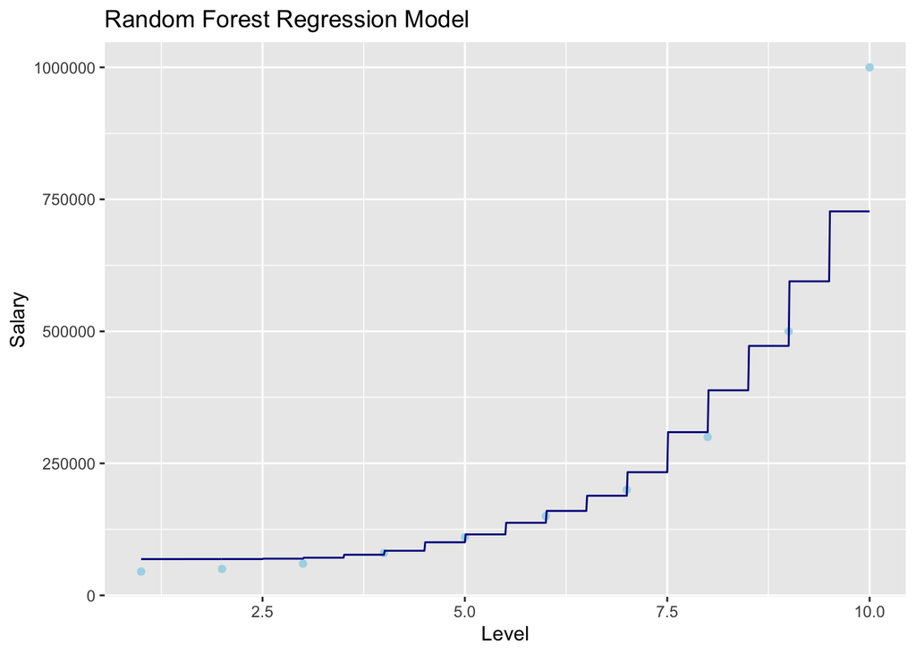

```r
# Increase the resolution
x_grid = seq(min(positions$Level), max(positions$Level), 0.01)

# Visualizing the random forest regression
ggplot() +
  geom_point(data = positions, aes(x = Level, y = Salary), col = 'lightblue') +
  geom_line(aes(x = x_grid, y = predict(regressor, newdata = data.frame(Level = x_grid))), col = 'darkblue') +
  ggtitle('Random Forest Regression Model') +
  xlab('Level') +
  ylab('Salary')
```